# konicek_homework_8

kelli

2025-03-12

# Libraries

```r
library(tidyverse)
library(car)
library(arm)
library(pwr)
```

### Dear Kyle, I did bad and started this the night before it was due. I ran into something my brain had to think about for more than two seconds and I guess that did me in. If I can resubmit this for a better grade later after I actually read and put in effort, I will do that.

Homework 8 – Replication, Statistical Power, and Type M Error

Imagine that you want to test how a warming climate affects primary production in grasslands.

You will perform an in situ warming experiment, in which you use ceramic heaters to warm 2 x 2 meter experimental plots by 4ºC, continuously for two years.

Control plots are unwarmed, and the treatment and control plots will be randomly assigned.

Biomass production is measured at the plot scale using appropriate methods.

# (1)

You have limited time and money, which means that the number of replicate treatment and control plots is limited. Before designing and performing the study, let’s consider how the number of replicates will affect our statistical power: our ability to detect an effect of warming.

Based on previous studies in similar environments, we can get a sense for what the effect size might be: in other words, the true magnitude of the warming effect.

We can also get a sense for how variable productivity is between plots in the same treatment, for reasons outside of our control (i.e., the residual noise).

Assume that the *true treatment mean is 460*, and the true *control mean is 415* (the numbers are above ground net primary production (ANPP) – grams per square meter per year).

Assume that the *standard deviation of the variation between plots is 110*. These numbers are based on real data synthesized in the attached paper by Lemoine et al.

Start by assuming three replicates each of the treatment and control plots.

*Perform 1000 simulations, where each time you draw three treatment ANPP values and three control ANPP values, using the appropriate means and standard deviation, from a normal distribution.*

```r
#make a function for the simulations

simulations <- function(x) {

#now put the simulation into a loop, to see how often the null relationship generates a significant p-value

#define the number of iterations of the simulation
nsims = 1000
#make a vector to save the estimated slope, f test p value for treatment effect
slope.saved = f.p.value.saved=plot= vector()

for (i in 1:nsims) {
#generate a predictor and a response
treat = rnorm(x, mean = 460, sd = 110)
ctrl = rnorm(x, mean = 415, sd = 110)
#For each random draw, fit a linear model testing for a treatment effect.
model = lm(treat ~ ctrl)
#save the slope estimate
slope.saved[i] = coef(model)[2]
#save p-value from an F-test for the treatment effect
f.p.value.saved[i] = Anova(model)$P[1]
}

# Calculate the proportion
proportion_under <- sum(f.p.value.saved < 0.05)/nsims

return(list(slope=slope.saved,p=f.p.value.saved,proportion= proportion_under, plot=plot))
}

sample.three <- simulations(3)
```

*At the end you should have 1000 p-values and 1000 coefficient values.*

I do!

*What proportion of the p-values are less than 0.05?*

```r
sample.three$proportion
```

```
## [1] 0.038
```

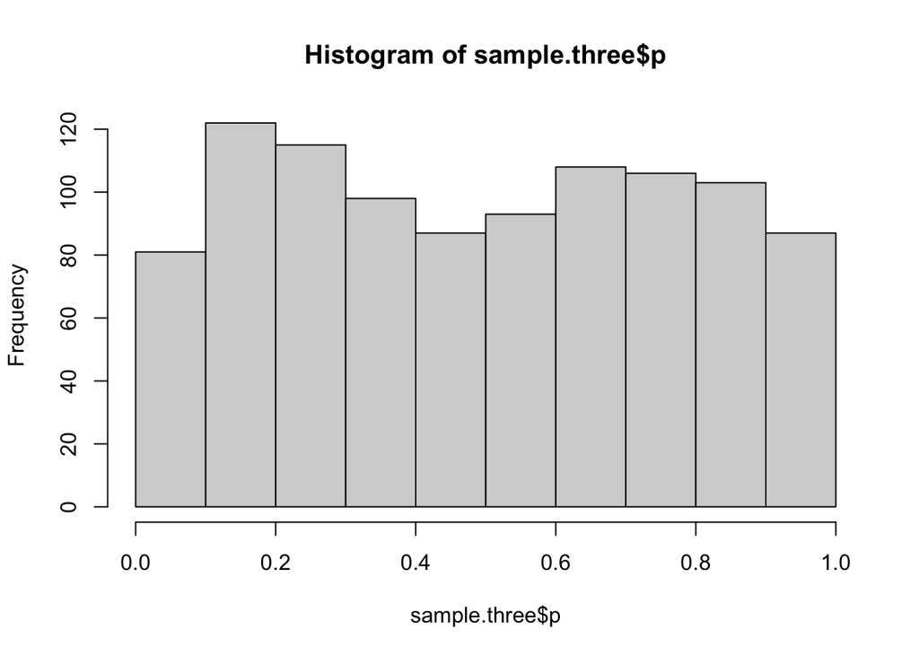

```r
hist(sample.three$p)
```

This is your statistical power, under this design, effect size, and residual noise. – is… is it?

*Now repeat this whole process using different numbers of replicates: 5, 10, 20, 50, 100.*

```r
sample.Afive <-simulations(5)

sample.Bten <-simulations(10)

sample.Ctwenty<-simulations(20)

sample.Dfifty<-simulations(50)

sample.Ehundo<-simulations(100)

sample.fuck <-simulations(10000)
```

ALRIGHT well I am confused, I think because I am missing something pretty fundamental– the coefficent slopes change when I up the sample size (x in my function), but not the p value. That makes sense since these aren’t actually related terms in my code, maybe? is that the part I have to change? This is the part where I had to think for a second and I guess I can’t do that anymore so I will ask my advisor if it’s time to hang my hat up and go twist on toothpaste caps at the toothpaste factory or somethin

*Plot the statistical power vs. the number of replicates.*

*How much replication do you need to achieve a power of 0.25?*

```r
n <- (460-415)/110
# Parameters
desired_power <- 0.25  # Desired power
alpha <- 0.05  # Significance level
effect_size <- n

# Calculate required sample size
power_result <- pwr.t.test(d = effect_size, sig.level = alpha, power = desired_power, type = "two.sample")

# Print the result
print(power_result)
```

```
##
##      Two-sample t test power calculation
##
##               n = 20.68414
##               d = 0.4090909
##       sig.level = 0.05
##           power = 0.25
##     alternative = two.sided
##
## NOTE: n is number in *each* group
```

Well if I just try to calculate this myself it seems like the 20 sample size should have a high enough proportion of p values under 0.05… but it’s essentially the same as all the other ones each time I do the simulation?

This means that when there is a real treatment effect, you will detect it (only) 25% of the time.

# (2)- none of this is done

Now let’s use the simulation results to answer a different question. For situations where statistical power is low, a treatment effect can only be ‘significant’ if it is quite large, and this may cause the treatment effect to be exaggerated by chance. This has been termed Type M error, where the M stands for magnitude, because you are making an error about the magnitude of the effect (see the attached paper).

For each of the simulations you performed above, you saved the model coefficients. So you should have 1000 coefficients for each level of replication (3, 5, 10, 20, 50, 100).

*Take those coefficients, and for each level of replication calculate the mean of the coefficients using only models where p < 0.05.*

This is simulating the following process: if you perform the experiment, and p > 0.05, you report ‘no effect’, but if p < 0.05 you report ‘significant effect’. We want to know if the reported significant effects are biased.

*How does the mean of the significant coefficients change as the number of replicates increases?*

*How much larger is the simulated value from the significant experiments, compared to the true value?*

This is the type M error.

*What are the potential implications for our understanding of climate change, if most warming experiments have low power?*